# Automatización de selección de modelos, variables fijas y aleatorias e introducción a crossvalidation

03/11, 2020

## Variables fijas vs aleatorias

## Variables fijas vs aleatorias

- Fijas (continuas o categóricas)
  - Se espera que tengan una influencia predecible y sistemática en sobre lo que queremos explicar. Además usan todos los niveles de un factor (Ejemplo genero)
- Aleatorias
  - Se espera que su influencia sea impredecible e idiosincratica. Además no se usan todos los niveles de un factor (todos los individuos) A + Error(B)

## Ejemplo CO2

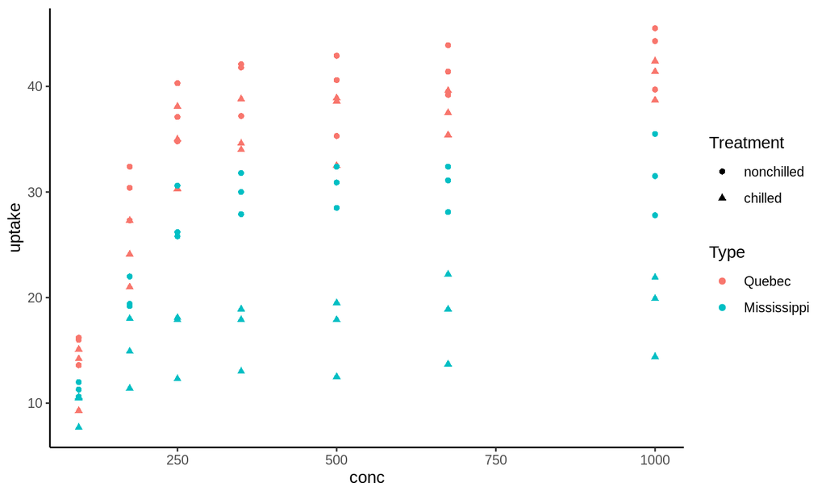

## Ejemplo CO2

| Plant | Type | Treatment | conc | uptake |
| --- | --- | --- | --- | --- |
| Qn1 | Quebec | nonchilled | 95 | 16.0 |
| Qn1 | Quebec | nonchilled | 175 | 30.4 |
| Qn1 | Quebec | nonchilled | 250 | 34.8 |
| Qn1 | Quebec | nonchilled | 350 | 37.2 |
| Qn1 | Quebec | nonchilled | 500 | 35.3 |
| Qn1 | Quebec | nonchilled | 675 | 39.2 |
| Qn1 | Quebec | nonchilled | 1000 | 39.7 |
| Qn2 | Quebec | nonchilled | 95 | 13.6 |
| Qn2 | Quebec | nonchilled | 175 | 27.3 |
| Qn2 | Quebec | nonchilled | 250 | 37.1 |
| Qn2 | Quebec | nonchilled | 350 | 41.8 |
| Qn2 | Quebec | nonchilled | 500 | 40.6 |
| Qn2 | Quebec | nonchilled | 675 | 41.4 |
| Qn2 | Quebec | nonchilled | 1000 | 44.3 |
| Qn3 | Quebec | nonchilled | 95 | 16.2 |
| Qn3 | Quebec | nonchilled | 175 | 32.4 |
| Qn3 | Quebec | nonchilled | 250 | 40.3 |
| Qn3 | Quebec | nonchilled | 350 | 42.1 |
| Qn3 | Quebec | nonchilled | 500 | 42.9 |
| Qn3 | Quebec | nonchilled | 675 | 43.9 |
| Qn3 | Quebec | nonchilled | 1000 | 45.5 |
| Qc1 | Quebec | chilled | 95 | 14.2 |
| Qc1 | Quebec | chilled | 175 | 24.1 |
| Qc1 | Quebec | chilled | 250 | 30.3 |
| Qc1 | Quebec | chilled | 350 | 34.6 |
| Qc1 | Quebec | chilled | 500 | 32.5 |
| Qc1 | Quebec | chilled | 675 | 35.4 |
| Qc1 | Quebec | chilled | 1000 | 38.7 |
| Qc2 | Quebec | chilled | 95 | 9.3 |
| Qc2 | Quebec | chilled | 175 | 27.3 |

[output cut: 54 more lines]

## Modelos

```r
library(lme4)
mod1 <- lm(uptake ~ Type * Treatment + I(log(conc)) + conc, data = CO2)
mod2 <- lmer(uptake ~ Type * Treatment + I(log(conc)) + conc + (1 | Plant), data = CO2)
```

```r
options(na.action = "na.fail")
Max.Vars <- floor(nrow(CO2)/10)
Seleccion <- dredge(mod2, m.lim = c(0, Max.Vars))
```

## Selección

(Intercept)

conc

I(log(conc))

Treatment

Type

Treatment:Type

df

logLik

AICc

delta

weight

-57.247

-0.025

17.789

8

-230.705

479.331

0.000

0.963

-55.608

-0.025

17.789

NA

7

-235.188

485.850

6.519

0.037

-59.037

-0.025

17.789

NA

NA

6

-241.972

497.036

17.705

0.000

-14.037

NA

8.484

7

-241.168

497.809

18.478

0.000

-12.398

NA

8.484

NA

6

-245.650

504.392

25.061

0.000

-61.937

-0.025

17.789

NA

NA

6

-246.728

506.546

27.215

0.000

-65.367

-0.025

17.789

NA

NA

NA

5

-250.329

511.428

32.097

0.000

-15.827

NA

8.484

NA

NA

5

-252.435

515.638

36.307

0.000

-18.727

NA

8.484

NA

NA

5

-257.190

525.149

45.818

0.000

-22.157

NA

8.484

NA

NA

NA

4

-260.792

530.089

50.759

0.000

27.621

0.018

NA

7

-267.614

550.702

71.371

0.000

29.260

0.018

NA

NA

6

-272.096

557.284

77.953

0.000

25.830

0.018

NA

NA

NA

5

-278.881

568.530

89.200

0.000

22.930

0.018

NA

NA

NA

5

-283.636

578.041

98.710

0.000

19.500

0.018

NA

NA

NA

NA

4

-287.238

582.982

103.651

0.000

35.333

NA

NA

6

-286.019

585.128

105.798

0.000

36.973

NA

NA

NA

5

-289.930

590.630

111.299

0.000

33.543

NA

NA

NA

NA

4

-296.656

601.819

122.488

0.000

30.643

NA

NA

NA

NA

4

-301.412

611.330

131.999

0.000

27.213

NA

NA

NA

NA

NA

3

-305.013

616.327

136.996

0.000

Solo el primer modelo es seleccionado

## Modelo

```r
BestModel <- get.models(Seleccion, 1)[[1]]
broom.mixed::tidy(BestModel)
```

| effect | group | term | estimate | std.error | statistic |
| --- | --- | --- | --- | --- | --- |
| fixed | NA | (Intercept) | -57.247 | 7.867 | -7.277 |
| fixed | NA | conc | -0.025 | 0.004 | -6.075 |
| fixed | NA | I(log(conc)) | 17.789 | 1.622 | 10.970 |
| fixed | NA | Treatmentchilled | -3.581 | 1.835 | -1.952 |
| fixed | NA | TypeMississippi | -9.381 | 1.835 | -5.112 |
| fixed | NA | Treatmentchilled:TypeMississippi | -6.557 | 2.595 | -2.527 |
| ran_pars | Plant | sd__(Intercept) | 1.769 | NA | NA |
| ran_pars | Residual | sd__Observation | 3.667 | NA | NA |

## Modelo

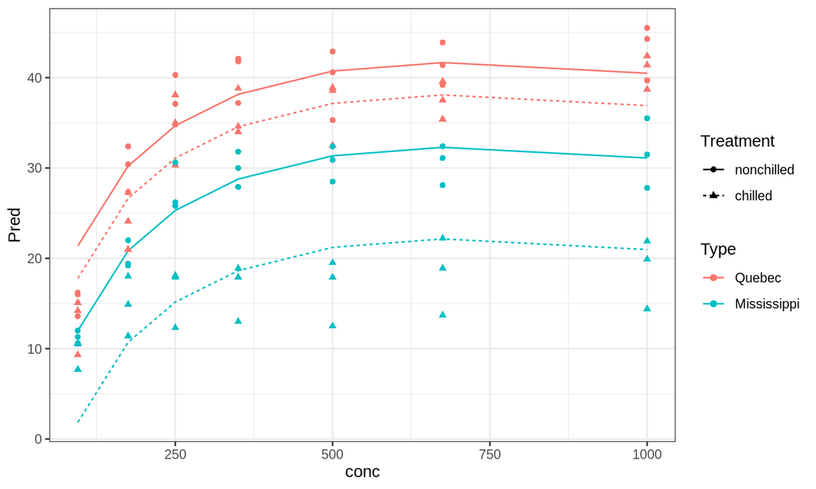

## Control mas detallado de dredge en MuMin

## Cemento

- ¿Que problema tiene la siguiente base de datos para LMs o GLMs?
- Ejemplo base de datos `Cement` de MuMIn

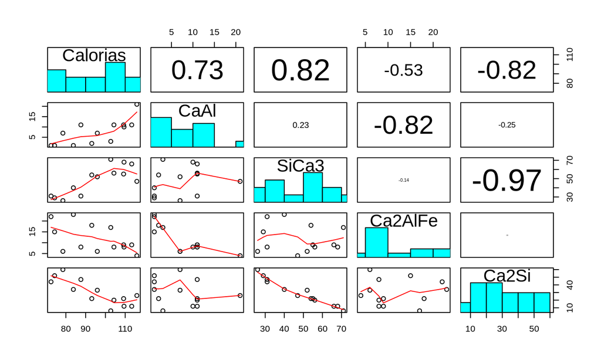

## Como agrego eso a MuMIn

```r
GlobalMod <- lm(Calorias ~ ., data = Cement2)
```

```r
cor(Cement2[, -1])
```

|  | CaAl | SiCa3 | Ca2AlFe | Ca2Si |
| --- | --- | --- | --- | --- |
| CaAl | 1.0000000 | 0.2285795 | -0.8241338 | -0.2454451 |
| SiCa3 | 0.2285795 | 1.0000000 | -0.1392424 | -0.9729550 |
| Ca2AlFe | -0.8241338 | -0.1392424 | 1.0000000 | 0.0295370 |
| Ca2Si | -0.2454451 | -0.9729550 | 0.0295370 | 1.0000000 |

## Como agrego eso a MuMIn (cont)

```r
nm <- colnames(Cement2[-1])
smat <- abs(cor(Cement2[, -1])) <= 0.7
smat[!lower.tri(smat)] <- NA
```

|  | CaAl | SiCa3 | Ca2AlFe | Ca2Si |
| --- | --- | --- | --- | --- |
| CaAl | NA | NA | NA | NA |
| SiCa3 | TRUE | NA | NA | NA |
| Ca2AlFe | FALSE | TRUE | NA | NA |
| Ca2Si | TRUE | FALSE | TRUE | NA |

## Como agrego eso a MuMIn (cont)

```r
options(na.action = "na.fail")
Selected <- dredge(GlobalMod, subset = smat)
```

| (Intercept) | Ca2AlFe | Ca2Si | CaAl | SiCa3 | df | logLik | AICc | delta | weight |
| --- | --- | --- | --- | --- | --- | --- | --- | --- | --- |
| 52.58 | NA | NA | 1.47 | 0.66 | 4 | -28.16 | 69.31 | 0.00 | 0.84 |
| 103.10 | NA | -0.61 | 1.44 | NA | 4 | -29.82 | 72.63 | 3.32 | 0.16 |
| 131.28 | -1.20 | -0.72 | NA | NA | 4 | -35.37 | 83.74 | 14.43 | 0.00 |
| 72.07 | -1.01 | NA | NA | 0.73 | 4 | -40.96 | 94.93 | 25.62 | 0.00 |
| 117.57 | NA | -0.74 | NA | NA | 3 | -45.87 | 100.41 | 31.10 | 0.00 |
| 57.42 | NA | NA | NA | 0.79 | 3 | -46.04 | 100.74 | 31.42 | 0.00 |
| 81.48 | NA | NA | 1.87 | NA | 3 | -48.21 | 105.08 | 35.77 | 0.00 |
| 110.20 | -1.26 | NA | NA | NA | 3 | -50.98 | 110.63 | 41.31 | 0.00 |
| 95.42 | NA | NA | NA | NA | 2 | -53.17 | 111.54 | 42.22 | 0.00 |

## Incluir además límite de numero de variables

```r
options(na.action = "na.fail")
Selected <- dredge(GlobalMod, subset = smat, m.lim = c(0, floor(nrow(Cement)/10)))
```

| (Intercept) | Ca2AlFe | Ca2Si | CaAl | SiCa3 | df | logLik | AICc | delta | weight |
| --- | --- | --- | --- | --- | --- | --- | --- | --- | --- |
| 117.57 | NA | -0.74 | NA | NA | 3 | -45.87 | 100.41 | 0.00 | 0.51 |
| 57.42 | NA | NA | NA | 0.79 | 3 | -46.04 | 100.74 | 0.33 | 0.43 |
| 81.48 | NA | NA | 1.87 | NA | 3 | -48.21 | 105.08 | 4.67 | 0.05 |
| 110.20 | -1.26 | NA | NA | NA | 3 | -50.98 | 110.63 | 10.22 | 0.00 |
| 95.42 | NA | NA | NA | NA | 2 | -53.17 | 111.54 | 11.13 | 0.00 |

## Crossvalidation

## A veces no se pueden usar criterios de información

- No se pueden calcular IC
- No se cumplen supuestos de criterios de información
- Comparacion entre distintos tipos de modelos (GLM, vs GAM vs RPART, etc)
- Se aplican distintas transformaciones a la variable respuesta (GLM)
- Varios terminos polinomiales (no se debe promediar modelos)

## Alternativas a los métodos de criterios de información

- Simular que presentamos datos nuevos
  - Crossvalidation
  - Bootstrapping
  - Leave one out

## k-fold Crossvalidation

- Divido aleatoreamente mi base de datos en \(k\) grupos
- Entreno mis modelos con \(k-1\) grupos
- Testeo con el grupo \(k_i\)
- Promedio medida de desempeño por ejemplo \(R^2\)

## Volvamos al ejemplo de hp

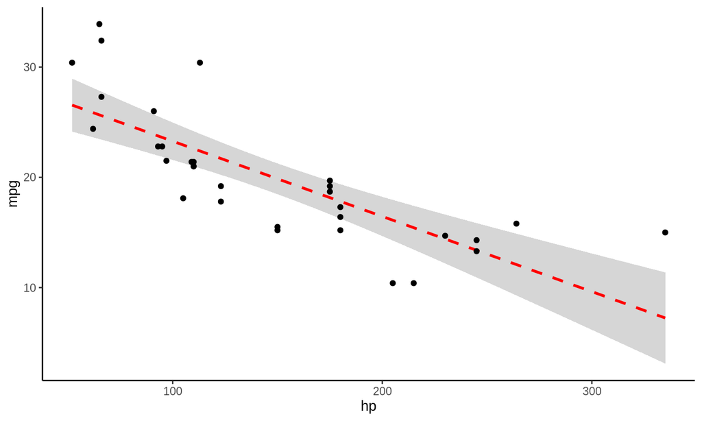

- Veamos como evaluamos 1 modelo \(mpg = \beta_1 hp +c\)
- \(R^2\) = 0.6

Paso 1 K-fold

## Divido my base en K

- En este caso K = 5
  - Dividiremos nuestra base de datos en 5 partes iguales

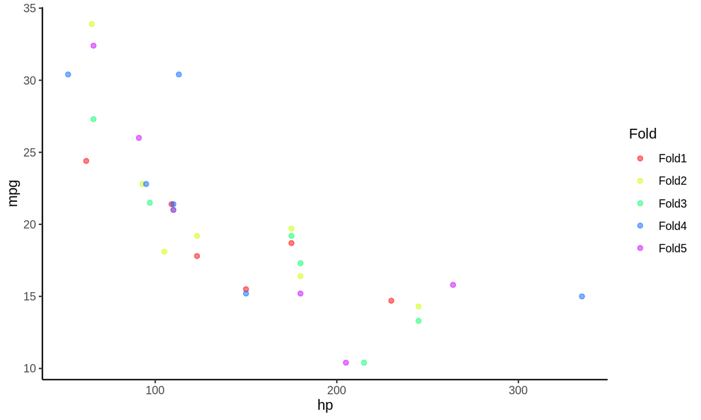

## Paso 2 Entreno y testeo para cada K

## Fold 1

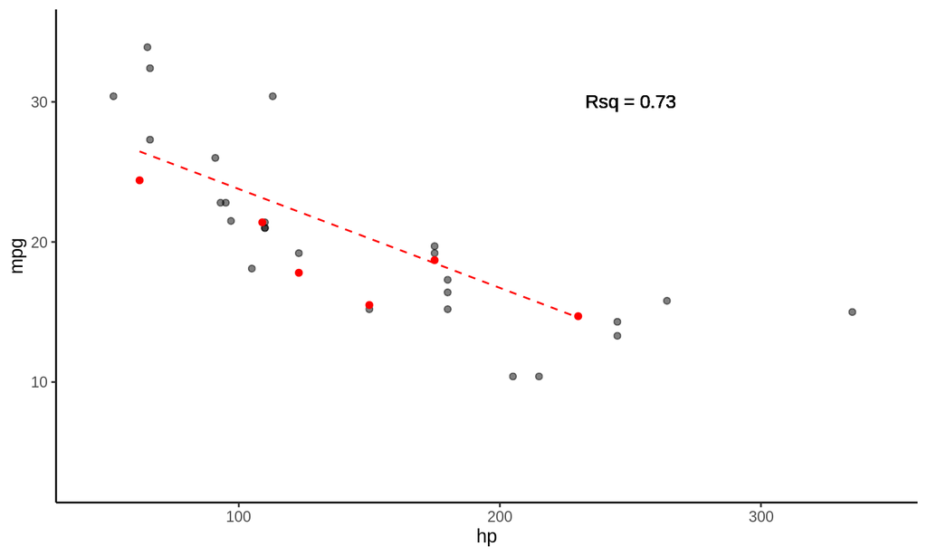

- Rsq = 0.73

## Fold 2

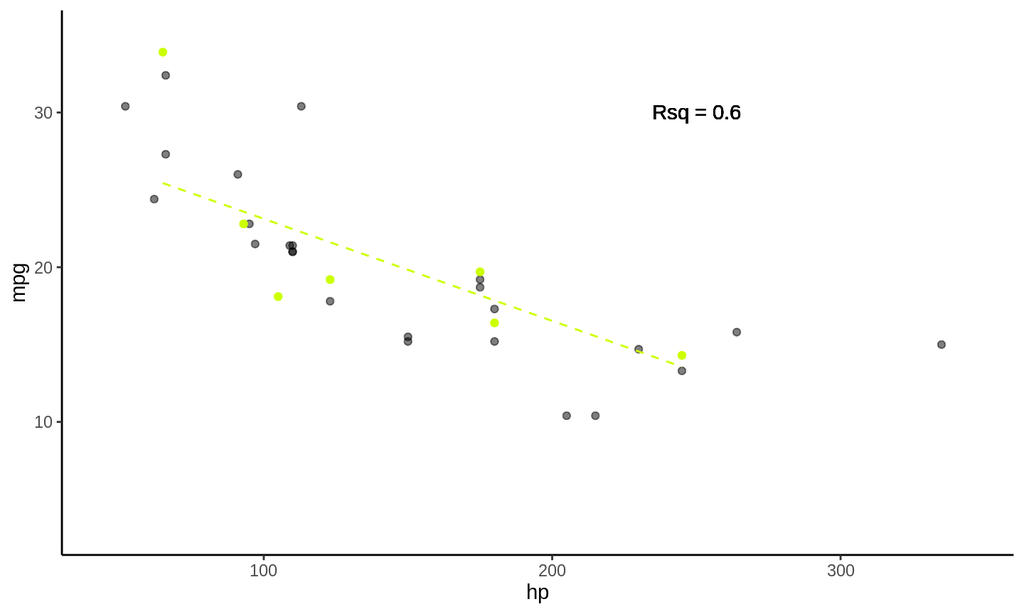

- Rsq = 0.73, 0.6

## Fold 3

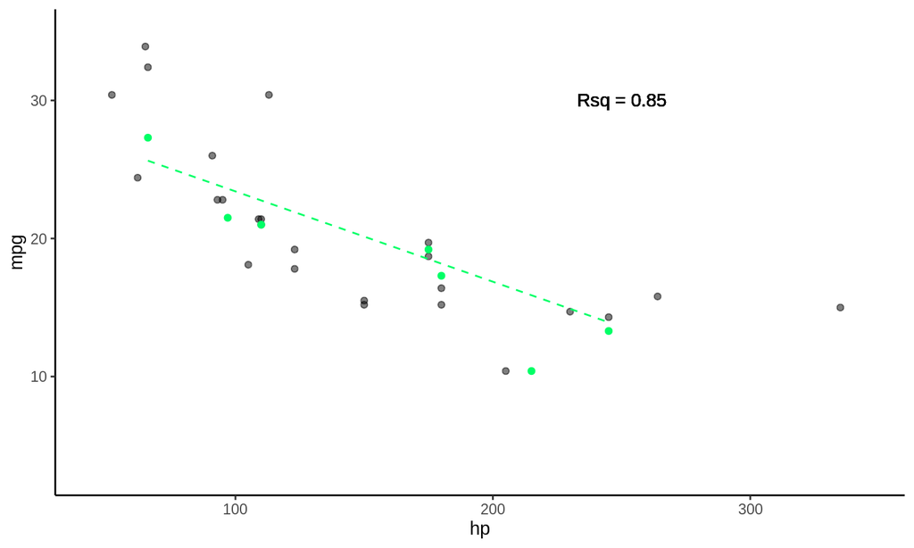

- Rsq = 0.73, 0.6, 0.85

## Fold 4

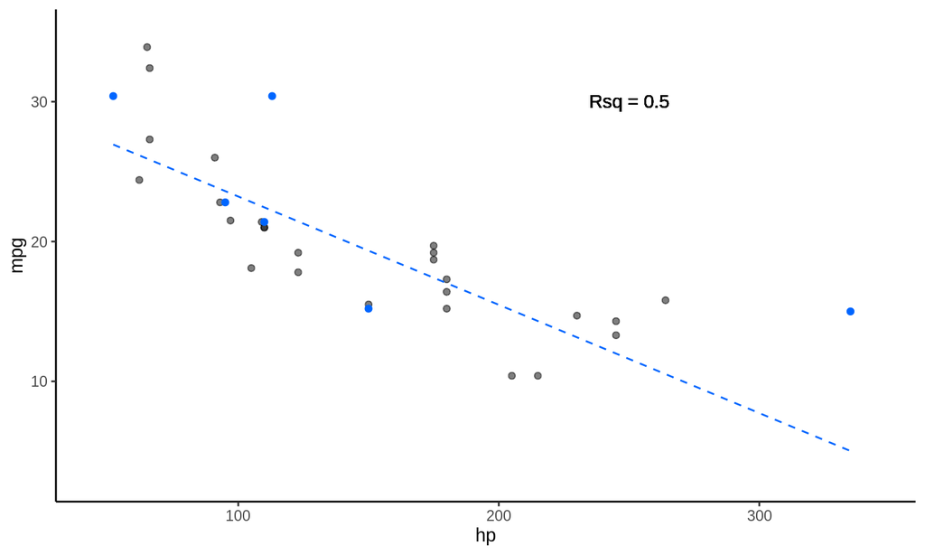

- Rsq = 0.73, 0.6, 0.85, 0.5

## Fold 5

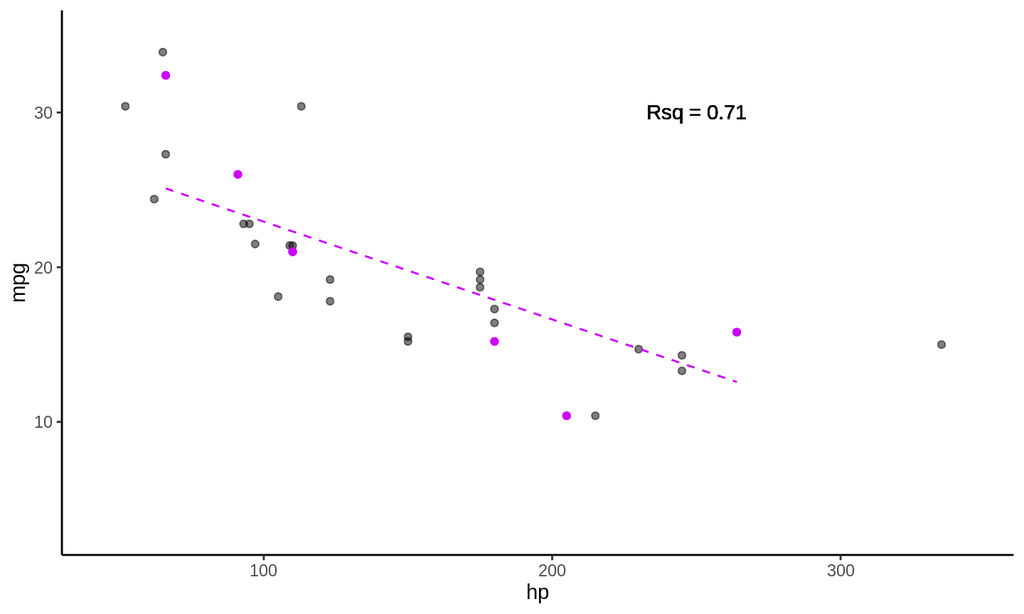

- Rsq = 0.73, 0.6, 0.85, 0.5, 0.71
- Rsq = 0.678

## Con Caret

## CV en caret

- para 1 modelo

```r
set.seed(2020)
ctrl <- trainControl(method = "cv", number = 5)
Modelo <- train(mpg ~ hp, data = mtcars, method = "lm", trControl = ctrl)
DF <- Modelo$resample
DF <- DF %>% select(Rsquared, Resample)
```

## Continuado

| Rsquared | Resample |
| --- | --- |
| 0.845 | Fold1 |
| 0.921 | Fold2 |
| 0.603 | Fold3 |
| 0.832 | Fold4 |
| 0.783 | Fold5 |

## Seleccionando por crossvalidation

```r
form1 <- "mpg ~ hp"
form2 <- "mpg ~ hp + I(hp^2)"
form3 <- "mpg ~ hp + I(hp^2) + I(hp^3)"
form4 <- "mpg ~ hp + I(hp^2) + I(hp^3) + I(hp^4)"
form5 <- "mpg ~ hp + I(hp^2) + I(hp^3) + I(hp^4) + I(hp^5)"
form6 <- "mpg ~ hp + I(hp^2) + I(hp^3) + I(hp^4) + I(hp^5) + I(hp^6)"
forms <- list(form1, form2, form3, form4, form5, form6)
K = (2:7)
ctrl <- trainControl(method = "cv", number = 5)
```

## Continuado

```r
set.seed(2020)
Tests <- forms %>% map(~train(as.formula(.x),
    data = mtcars, method = "lm",
    trControl = ctrl)) %>% map(~as.data.frame(.x$resample)) %>%
    map(~select(.x, Rsquared)) %>%
    map(~summarise_all(.x, funs(mean,
        sd), na.rm = T)) %>% map2(.y = forms,
    ~mutate(.x, model = .y)) %>%
    reduce(bind_rows) %>% mutate(K = K) %>%
    arrange(desc(mean))
```

## Continuado

| mean | sd | model | K |
| --- | --- | --- | --- |
| 0.808 | 0.116 | mpg ~ hp + I(hp^2) + I(hp^3) | 4 |
| 0.797 | 0.119 | mpg ~ hp | 2 |
| 0.786 | 0.128 | mpg ~ hp + I(hp^2) | 3 |
| 0.705 | 0.326 | mpg ~ hp + I(hp^2) + I(hp^3) + I(hp^4) + I(hp^5) | 6 |
| 0.656 | 0.374 | mpg ~ hp + I(hp^2) + I(hp^3) + I(hp^4) | 5 |
| 0.618 | 0.302 | mpg ~ hp + I(hp^2) + I(hp^3) + I(hp^4) + I(hp^5) + I(hp^6) | 7 |

## Entender la hipótesis estadística a generar basado en la hipótesis biológica

## Pregunta 1

- ¿Cual de estas relaciones es la que uno esperaría ver al finalizar el experimento?

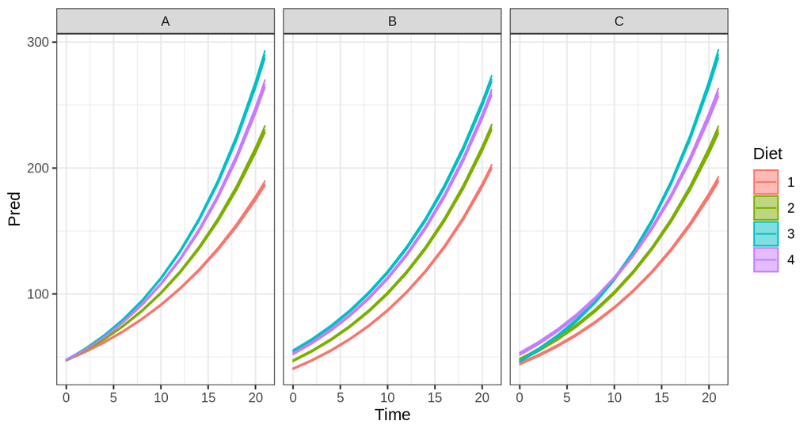

- Respuesta: A

## Pregunta 2

- ¿Cuál de estos códigos resultaría en el modelo que generaría este gráfico?

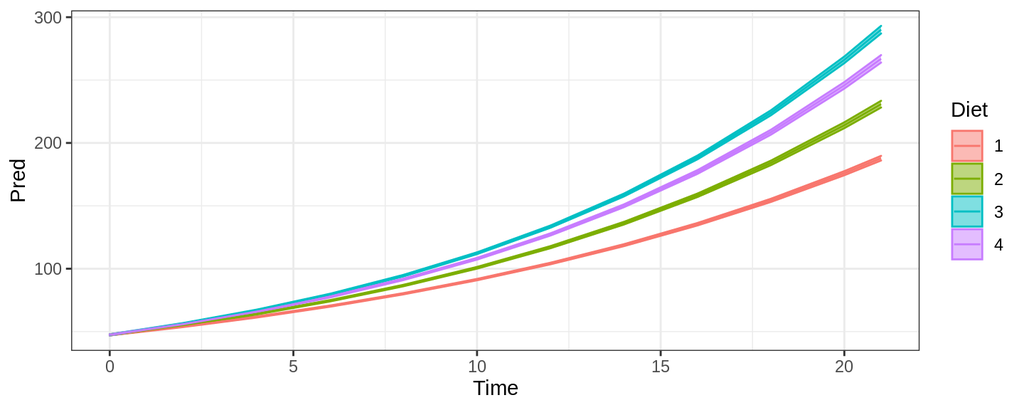

```r
A <- glm(weight ~ Time + Diet, family = poisson)
B <- glm(weight ~ Time * Diet, family = poisson)
C <- glm(weight ~ Time + Time:Diet, family = poisson)
```

## Pregunta 2 (cont)

```r
library(lme4)
ChickPoissMM1 <- glmer(weight ~ Time + Diet + (1 | Chick), family = poisson,
    data = ChickWeight)
ChickPoissMM2 <- glmer(weight ~ Time + Time:Diet + (1 | Chick),
    family = poisson, data = ChickWeight)
ChickPoissMM3 <- glmer(weight ~ Time + Time * Diet + (1 | Chick),
    family = poisson, data = ChickWeight)
```

## Pregunta 3

- ¿Cuanto pesaria un pollo en el dia 10 en la dieta 2 basado en el modelo anterior?

| effect | group | term | estimate | std.error | statistic | p.value |
| --- | --- | --- | --- | --- | --- | --- |
| fixed | NA | (Intercept) | 3.84 | 0.03 | 121.74 | 0 |
| fixed | NA | Time | 0.07 | 0.00 | 63.72 | 0 |
| fixed | NA | Time:Diet2 | 0.01 | 0.00 | 4.99 | 0 |
| fixed | NA | Time:Diet3 | 0.02 | 0.00 | 12.59 | 0 |
| fixed | NA | Time:Diet4 | 0.01 | 0.00 | 5.91 | 0 |
| ran_pars | Chick | sd__(Intercept) | 0.21 | NA | NA | NA |

- A = 94.6324083
- B = 113.2955623
- C = 4.73

## Pregunta 3 (cont)

```r
exp(3.83 + 10 * 0.07 + 0.02)
```

```
## [1] 94.63241
```

```r
exp(3.83 + 10 * 0.07 + (10 * 0.02))
```

```
## [1] 113.2956
```

```r
3.83 + 10 * 0.07 + (10 * 0.02)
```

```
## [1] 4.73
```

## Pregunta 4

- ¿Cuál es el código que mejor representa este gráfico?

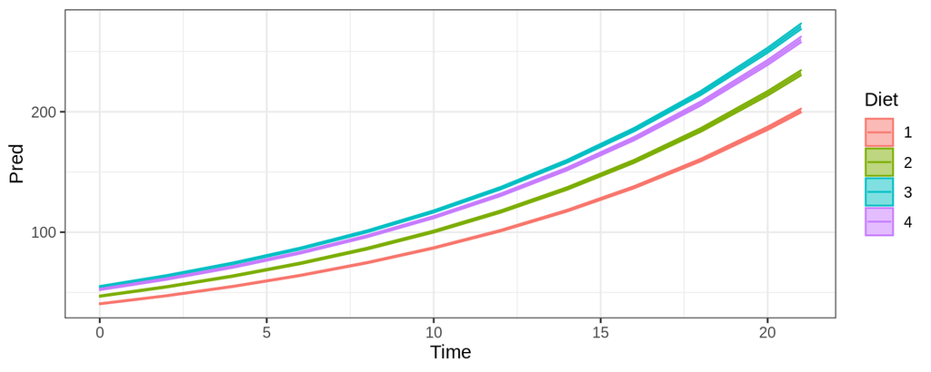

```r
A <- glm(weight ~ Time + Diet, family = poisson)
B <- glm(weight ~ Time * Diet, family = poisson)
C <- glm(weight ~ Time + Time:Diet, family = poisson)
```

## Pregunta 5

- ¿Cuantas pendientes e interceptos espero ver en este modelo?

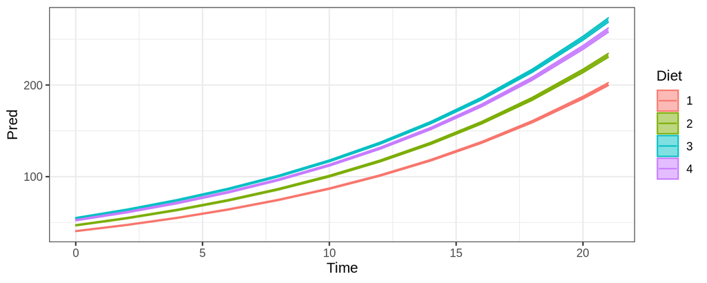

## Pregunta 5 (cont)

| term | estimate | std.error | statistic | p.value |
| --- | --- | --- | --- | --- |
| (Intercept) | 3.70 | 0.01 | 346.30 | 0 |
| Time | 0.08 | 0.00 | 125.25 | 0 |
| Diet2 | 0.15 | 0.01 | 13.69 | 0 |
| Diet3 | 0.30 | 0.01 | 29.46 | 0 |
| Diet4 | 0.26 | 0.01 | 24.88 | 0 |